# Лабораторная работа №8

Адресация IPv4 и IPv6. Настройка маршрутизации

Владимир Базлов

Российский университет дружбы народов, Москва, Россия

15 декабря 2025

# Цель работы

## Основная цель

Изучить принципы адресации в сетях IPv4 и IPv6  
и освоить настройку динамической маршрутизации  
с использованием протокола RIP.

# Топология сети

## Моделируемая сеть

В среде GNS3 была построена сеть, включающая: - 4 маршрутизатора FRR - 2 коммутатора - 2 оконечных устройства VPCS

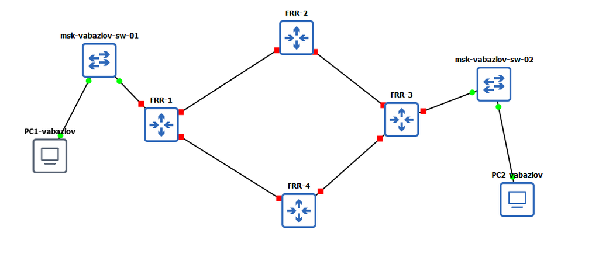

Топология моделируемой сети

# Адресация IPv4

## IPv4-адресация оконечных устройств

Для оконечных устройств PC1 и PC2 вручную заданы IPv4-адреса  
и соответствующие шлюзы по умолчанию.

[figure not shown]

Настройка IPv4 на PC1

## IPv4-адресация оконечных устройств

[figure not shown]

Настройка IPv4 на PC2

## IPv4-адресация маршрутизаторов

[figure not shown]

IPv4 на msk-vabazlov-gw-01

## IPv4-адресация маршрутизаторов

[figure not shown]

IPv4 на msk-vabazlov-gw-02

## IPv4-адресация маршрутизаторов

[figure not shown]

IPv4 на msk-vabazlov-gw-03

## IPv4-адресация маршрутизаторов

[figure not shown]

IPv4 на msk-vabazlov-gw-04

# Адресация IPv6

## IPv6-адресация оконечных устройств

[figure not shown]

IPv6 на PC1

## IPv6-адресация оконечных устройств

[figure not shown]

IPv6 на PC2

## IPv6-адресация маршрутизаторов

На маршрутизаторах включена маршрутизация IPv6  
и назначены IPv6-адреса на всех интерфейсах.

Для сегментов с оконечными устройствами разрешена  
рассылка Router Advertisements.

## IPv6-адресация маршрутизаторов

[figure not shown]

IPv6 на msk-vabazlov-gw-01

## IPv6-адресация маршрутизаторов

[figure not shown]

IPv6 на msk-vabazlov-gw-02

## IPv6-адресация маршрутизаторов

[figure not shown]

IPv6 на msk-vabazlov-gw-03

## IPv6-адресация маршрутизаторов

[figure not shown]

IPv6 на msk-vabazlov-gw-04

# Динамическая маршрутизация RIP

## Протокол RIP версии 2

Для динамического обмена маршрутной информацией  
на всех маршрутизаторах настроен протокол RIP версии 2.

Особенности RIPv2: - дистанционно-векторный протокол - метрика — количество переходов - максимальное число хопов — 15 - многоадресная рассылка на 224.0.0.9

## Настройка RIP на маршрутизаторах

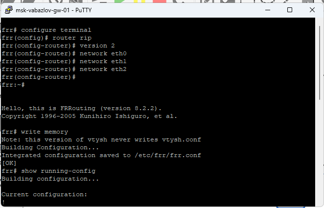

RIP на msk-vabazlov-gw-01

## Настройка RIP на маршрутизаторах

[figure not shown]

RIP на msk-vabazlov-gw-02

## Настройка RIP на маршрутизаторах

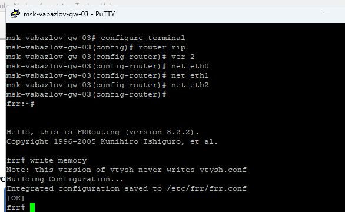

RIP на msk-vabazlov-gw-03

## Настройка RIP на маршрутизаторах

[figure not shown]

RIP на msk-vabazlov-gw-04

## Проверка таблиц маршрутизации

После настройки RIP выполнена проверка: - полученных маршрутов - метрик - источников обновлений

[figure not shown]

Таблица маршрутизации RIP

# Проверка связности

## Проверка маршрутизации

С устройства PC1 выполнена проверка связности  
с устройством PC2 с использованием ICMP.

[figure not shown]

Ping PC1 → PC2

## Трассировка маршрута

Для анализа пути следования пакетов  
выполнена трассировка маршрута.

[figure not shown]

# Анализ трафика RIP

## Захват и анализ RIP-пакетов

[figure not shown]

Анализ RIP-трафика

# Итоги работы

## Выводы

- Построена и настроена модель сети в GNS3
- Реализована адресация IPv4 и IPv6
- Настроена динамическая маршрутизация RIPv2
- Проверена связность и корректность маршрутизации
- Выполнен анализ RIP-трафика

Работа протоколов адресации и маршрутизации  
подтверждена экспериментально.